# 20201119-p8157_hw4_jsg2145

Jared Garfinkel

11/19/2020

### Read in data

```r
data = read_delim(file = "./data/toenail.txt", delim = " ", col_names = c("id", "y", "treatment", "month", "visit"), skip = 1)

data
```

```
## # A tibble: 1,908 x 5
##       id     y treatment  month visit
##    <dbl> <dbl>     <dbl>  <dbl> <dbl>
##  1     1     1         1  0         1
##  2     1     1         1  0.857     2
##  3     1     1         1  3.54      3
##  4     1     0         1  4.54      4
##  5     1     0         1  7.54      5
##  6     1     0         1 10.0       6
##  7     1     0         1 13.1       7
##  8     2     0         0  0         1
##  9     2     0         0  0.964     2
## 10     2     1         0  2         3
## # ... with 1,898 more rows
```

# Question 1

## Part 1

```r
df = data %>%
  data.table()
# add response at lag 1
df[,y_1 := shift(y,n=1,type="lag", fill = NA), by = "id"]
## transition probabilities
tab1 <- table(df$y, df$y_1)
tab1
```

```
##
##        0    1
##   0 1203  112
##   1   28  271
```

```r
round(prop.table(tab1,margin = 1),2)
```

```
##
##        0    1
##   0 0.91 0.09
##   1 0.09 0.91
```

```r
# df
model_lag_1 <- gee(y ~ treatment * (y_1 + month), corstr = "independence", family = binomial("logit"), id = id, data = df)
```

```
##     (Intercept)       treatment             y_1           month   treatment:y_1
##     -2.91754387     -0.58731398      4.20408170     -0.09042707      0.69205101
## treatment:month
##     -0.05921630
```

```r
round(summary(model_lag_1)$coeff,2)
```

```
##                 Estimate Naive S.E. Naive z Robust S.E. Robust z
## (Intercept)        -2.92       0.32   -9.05        0.30    -9.58
## treatment          -0.59       0.53   -1.10        0.48    -1.21
## y_1                 4.20       0.31   13.40        0.33    12.57
## month              -0.09       0.04   -2.24        0.04    -2.31
## treatment:y_1       0.69       0.52    1.33        0.49     1.40
## treatment:month    -0.06       0.07   -0.91        0.07    -0.81
```

## Part 2

```r
df2 = data %>%
  data.table()
# add response at lag 1
df[,y_2 := shift(y,n=2,type="lag", fill = NA), by = "id"]
df2[,y_2 := shift(y,n=2,type="lag", fill = NA), by = "id"]
## transition probabilities
tab2 <- table(df$y, df$y_2)
tab2
```

```
##
##       0   1
##   0 934 189
##   1  33 169
```

```r
round(prop.table(tab2,margin = 1),2)
```

```
##
##        0    1
##   0 0.83 0.17
##   1 0.16 0.84
```

```r
model_lag_2 <- gee(y ~ treatment * (y_2 + month), corstr = "independence", family = binomial("logit"), id = id, data = df2)
```

```
##     (Intercept)       treatment             y_2           month   treatment:y_2
##     -2.34626955     -0.24951642      2.99108562     -0.12274020      0.28338438
## treatment:month
##     -0.05748224
```

```r
round(summary(model_lag_2)$coeff,2)
```

```
##                 Estimate Naive S.E. Naive z Robust S.E. Robust z
## (Intercept)        -2.35       0.33   -7.06        0.38    -6.20
## treatment          -0.25       0.51   -0.49        0.57    -0.44
## y_2                 2.99       0.30    9.83        0.36     8.38
## month              -0.12       0.04   -3.08        0.05    -2.61
## treatment:y_2       0.28       0.47    0.60        0.54     0.53
## treatment:month    -0.06       0.06   -0.90        0.08    -0.68
```

```r
model_lag_2b <- gee(y ~ treatment * (y_1 + y_2 + month), corstr = "independence", family = binomial("logit"), id = id, data = df)
```

```
##     (Intercept)       treatment             y_1             y_2           month
##     -3.05941334     -0.43737470      3.29362134      0.74239666     -0.05985574
##   treatment:y_1   treatment:y_2 treatment:month
##      2.36414282     -1.78090434     -0.06984192
```

```r
round(summary(model_lag_2b)$coeff,2)
```

```
##                 Estimate Naive S.E. Naive z Robust S.E. Robust z
## (Intercept)        -3.06       0.40   -7.70        0.39    -7.88
## treatment          -0.44       0.65   -0.67        0.60    -0.73
## y_1                 3.29       0.48    6.89        0.38     8.74
## y_2                 0.74       0.47    1.57        0.37     2.01
## month              -0.06       0.04   -1.35        0.04    -1.34
## treatment:y_1       2.36       1.06    2.22        0.94     2.51
## treatment:y_2      -1.78       1.02   -1.74        0.88    -2.03
## treatment:month    -0.07       0.07   -0.95        0.08    -0.88
```

A second order model shows significant association between the second order lag and the outcome. When the first order lag variable is added back in, the second order variable remains significant.

## Part 3

The treatment estimate is the log odds for those who were in treatment group B who had an identical status for onycholysis in the previous visit and the visit before that.

The y_1 and y_2 variables are the log odds for those with and without onycholysis in their previous visit or second previous visit who currently have an identical status for treatment group.

The month variable is the log odds of having onycholysis holding treatment group and the status of onycholysis in the previous visit or second previous visit constant.

Since the treatment effect is not found to be significant when the interactions are accounted for, it appears that there is not enough evidence to reject the null hypothesis that treatment A is associated with a change in the outcome of onycholysis.

For the interaction terms treatment:y_1 and treatment:y_2, the estimate is the difference in log odds for each lag comparing treatment B and treatment A groups with other covariates held fixed.

For the interaction term treatment:month, the estimate is the difference in log odds for each month comparing treatment B and treatment A groups with other covariates held fixed.

## Part 4

# Question 2

### Data cleaning

```r
toenail2 <- tidyr::complete(data, id, visit) %>%
  tidyr::fill(treatment)
toenail2 <- as.data.table(toenail2)
data_comp = complete(data, id, visit)
```

### Explore missingness

```r
M = data %>%
  pull(visit) %>%
  unique() %>%
  length()

data %>%
  group_by(id) %>%
  filter(length(unique(visit)) < M) %>%
  summarize(missingno = M - length(unique(visit))) %>%
  summarize(totalmissing = sum(missingno))
```

```
## # A tibble: 1 x 1
##   totalmissing
##          <int>
## 1          150
```

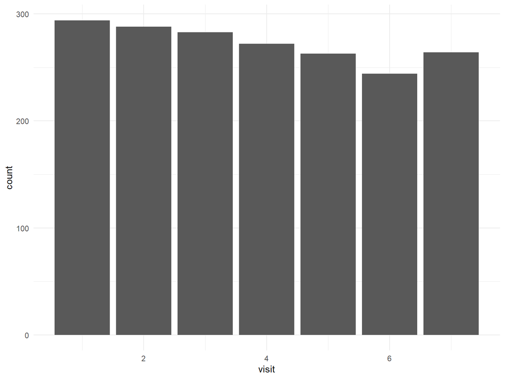

```r
data %>%
  ggplot(aes(x = visit, y = stat(count))) +
  geom_bar()
```

## Part 1

```r
table(data_comp$y,useNA = "always")
```

```
##
##    0    1 <NA>
## 1500  408  150
```

```r
data_comp = data_comp %>%
  data.table()
count <- data_comp[,j = list(n=sum(!is.na(y))), by = "id"]
table(count$n)
```

```
##
##   1   2   3   4   5   6   7
##   5   3   7   6  10  39 224
```

```r
count <- count[n==3]
data_comp1 <- data_comp[id %in% count$id]
table(data_comp1$y,useNA = "always")
```

```
##
##    0    1 <NA>
##   16    5   28
```

```r
table(data_comp1$treatment,data_comp1$y,useNA = "always")
```

```
##
##         0  1 <NA>
##   0     9  3    0
##   1     7  2    0
##   <NA>  0  0   28
```

```r
gee1 <- geeglm(y ~ treatment * visit, id = id, data = data_comp1, family = binomial(link = "logit"), corstr = "independence")
summary(gee1)
```

```
##
## Call:
## geeglm(formula = y ~ treatment * visit, family = binomial(link = "logit"),
##     data = data_comp1, id = id, corstr = "independence")
##
##  Coefficients:
##                 Estimate  Std.err  Wald Pr(>|W|)
## (Intercept)     -0.71734  1.20792 0.353  0.55260
## treatment        1.41975  2.02730 0.490  0.48373
## visit           -0.18094  0.08943 4.094  0.04304 *
## treatment:visit -0.90192  0.29006 9.668  0.00187 **
## ---
## Signif. codes:  0 '***' 0.001 '**' 0.01 '*' 0.05 '.' 0.1 ' ' 1
##
## Correlation structure = independence
## Estimated Scale Parameters:
##
##             Estimate Std.err
## (Intercept)   0.9418    0.52
## Number of clusters:   7  Maximum cluster size: 3
```

## Part 2

```r
data_comp2 <- data_comp
table(data_comp2$y,useNA = "always")
```

```
##
##    0    1 <NA>
## 1500  408  150
```

```r
table(data_comp2$treatment,data_comp2$y,useNA = "always")
```

```
##
##          0   1 <NA>
##   0    723 214    0
##   1    777 194    0
##   <NA>   0   0  150
```

```r
gee2 <- geeglm(y ~ treatment * visit, id = id, data = data_comp2, family = binomial(link = "logit"), corstr = "independence")
summary(gee2)
```

```
##
## Call:
## geeglm(formula = y ~ treatment * visit, family = binomial(link = "logit"),
##     data = data_comp2, id = id, corstr = "independence")
##
##  Coefficients:
##                 Estimate Std.err  Wald        Pr(>|W|)
## (Intercept)      -0.0325  0.2112  0.02            0.88
## treatment         0.1393  0.3106  0.20            0.65
## visit            -0.3348  0.0477 49.32 0.0000000000022 ***
## treatment:visit  -0.1057  0.0753  1.97            0.16
## ---
## Signif. codes:  0 '***' 0.001 '**' 0.01 '*' 0.05 '.' 0.1 ' ' 1
##
## Correlation structure = independence
## Estimated Scale Parameters:
##
##             Estimate Std.err
## (Intercept)    0.986   0.159
## Number of clusters:   294  Maximum cluster size: 7
```

## Part 3

```r
data = data %>%
  data.table()
data_comp3 <- lapply(unique(data$id), function(z){tidyr::fill(data[id == z], y)})
data_comp3 <- rbindlist(data_comp3)
table(data_comp3$treatment,data_comp3$y,useNA = "always")
```

```
##
##          0   1 <NA>
##   0    723 214    0
##   1    777 194    0
##   <NA>   0   0    0
```

```r
gee3 <- geeglm(y ~ treatment * visit, id = id, data = data_comp3, family = binomial(link = "logit"), corstr = "independence")
summary(gee3)
```

```
##
## Call:
## geeglm(formula = y ~ treatment * visit, family = binomial(link = "logit"),
##     data = data_comp3, id = id, corstr = "independence")
##
##  Coefficients:
##                 Estimate Std.err  Wald        Pr(>|W|)
## (Intercept)      -0.0325  0.2112  0.02            0.88
## treatment         0.1393  0.3106  0.20            0.65
## visit            -0.3348  0.0477 49.32 0.0000000000022 ***
## treatment:visit  -0.1057  0.0753  1.97            0.16
## ---
## Signif. codes:  0 '***' 0.001 '**' 0.01 '*' 0.05 '.' 0.1 ' ' 1
##
## Correlation structure = independence
## Estimated Scale Parameters:
##
##             Estimate Std.err
## (Intercept)    0.986   0.159
## Number of clusters:   294  Maximum cluster size: 7
```

## Part 4

```r
data4 <- data
pred <- make.predictorMatrix(data4)
pred
```

```
##           id y treatment month visit
## id         0 1         1     1     1
## y          1 0         1     1     1
## treatment  1 1         0     1     1
## month      1 1         1     0     1
## visit      1 1         1     1     0
```

```r
pred["y", "id"] <- -2
pred
```

```
##           id y treatment month visit
## id         0 1         1     1     1
## y         -2 0         1     1     1
## treatment  1 1         0     1     1
## month      1 1         1     0     1
## visit      1 1         1     1     0
```

```r
pred <- pred["y",,drop = FALSE]
pred
```

```
##   id y treatment month visit
## y -2 0         1     1     1
```

```r
data4$id <- as.integer(data4$id)
imp <- mice(data4, method = "2l.bin", pred = pred, seed = 719, maxit = 1, m = 5, print = FALSE, blocks = list(c("y")))
table(mice::complete(imp)$y, useNA = "always")
```

```
##
##    0    1 <NA>
## 1500  408    0
```

```r
implist <- mids2mitml.list(imp)
gee4 <- with(implist, geeglm(y ~ treatment * visit, id=id, family = binomial, corstr = "independence"))
testEstimates(gee4)
```

```
##
## Call:
##
## testEstimates(model = gee4)
##
## Final parameter estimates and inferences obtained from 5 imputed data sets.
##
##                  Estimate Std.Error   t.value        df   P(>|t|)       RIV       FMI
## (Intercept)        -0.033     0.211    -0.154       Inf     0.878     0.000     0.000
## treatment           0.139     0.311     0.449       Inf     0.654     0.000     0.000
## visit              -0.335     0.048    -7.023       Inf     0.000     0.000     0.000
## treatment:visit    -0.106     0.075    -1.404       Inf     0.160     0.000     0.000
##
## Unadjusted hypothesis test as appropriate in larger samples.
```

## Part 5

```r
lme1 <- mice::complete(imp, "all") %>%
    purrr::map(lme4::glmer,
               formula = y ~ treatment * visit + (1 | id),
               family = binomial) %>%
    pool() %>%
    summary()
```

```r
lme1
```

```
##              term estimate std.error statistic   df p.value
## 1     (Intercept)  -1.4252    0.8656   -1.6464 1901  0.0998
## 2       treatment  -0.0101    0.7836   -0.0129 1901  0.9897
## 3           visit  -0.8044    0.0892   -9.0149 1901  0.0000
## 4 treatment:visit  -0.2351    0.1261   -1.8643 1901  0.0624
```

When the visit is accounted for the treatment variable becomes not significant in the model. This is true using different assumptions about the model and in different imputation methods.